# Visualizing the Flow of Eviction Cases

mpc

2024-04-15

```r
library(tidyverse)

# potential viz packages
library(ggforce)
library(ggsankey)

# data
writs <- readRDS("../data/writ_matchedto_case.RDS")
cases <- readRDS("../data/case_matchedto_writ.RDS")

# uses writs_matchedto_case.RDS from writ_data.R
# uses case_matchedto_writ.RDS from writ_data.R
```

## Eviction Judgment to Writs

Using only the cases resulting in a judgment of eviction (e.g., default judgment or judgment for plaintiff), we can show the flow of cases through each subsequent outcome: type of judgment (may not be useful to include), whether a writ is issued, whether a writ is executed.

Below are two possible visual types.

```r
## derive measures
writs <- writs %>%
  mutate(dur_disp_date = interval(date_disposed, as.Date("2024-02-01")) / ddays(1),
         dur_writ_date = interval(writ_iss_date, as.Date("2024-02-01")) / ddays(1))


# Evictions (Eviction Judgment) ->
#   Judgment Type (Default, Plaintiff) ->
#     Writ Issued (Yes, No, Ongoing) ->
#       Writ Executed (Yes, No, Ongoing)
writs_categories <- writs %>%
  mutate(outcome = "Eviction\nJudgment",
        # these should take into account time since disposition
        writ_issued = case_when(
            # case is not yet disposed
            disposition == "Ongoing"  ~ "Ongoing",
            # case is disposed and writ issued date is present
            disposition != "Ongoing" & !is.na(writ_iss_date) ~ "Yes",
            # case is disposed, writ issue date is absent, but a writ could still happen
            disposition != "Ongoing" & is.na(writ_iss_date) & dur_disp_date <= 180 ~ "Ongoing",
            # case is disposed, writ issue date is absent, and it's too late to request a writ
            disposition != "Ongoing" & is.na(writ_iss_date) & dur_disp_date > 180  ~ "No",
            # one case with no dur_disp_date
            TRUE ~ "No"
            ),
         # these should take into account time since issued
         writ_executed = case_when(
           # case is not yet disposed
           disposition == "Ongoing" ~ "Ongoing",
           # case is disposed, writ is issued, writ execution date is present
           disposition != "Ongoing" & writ_issued == "Yes" & !is.na(writ_exec_date) ~ "Yes",
           # case is disposed, writ is issued, writ execution date is absent, but within 30 days
           disposition != "Ongoing" & writ_issued == "Yes" & is.na(writ_exec_date) & dur_writ_date <= 30  ~ "Ongoing",
           # case is disposed, writ is issued, writ execution date is absent, but over 30 days
           disposition != "Ongoing" & writ_issued == "Yes" & is.na(writ_exec_date) & dur_writ_date > 30 ~ "No",
           # case is disposed, writ is ongoing, writ execution date is absent
           disposition != "Ongoing" & writ_issued == "Ongoing" ~ "Ongoing",
           # case is disposed, writ is absent (and can't be requested)
           disposition != "Ongoing" & writ_issued == "No"  ~ "No",
           TRUE ~ "No"
         ),
         disposition = str_to_title(str_remove(disposition, " judgment")))
```

### ggforce::geom_parallel_sets

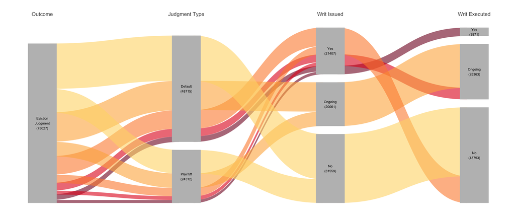

```r
# ggforce version
# https://ggforce.data-imaginist.com/reference/geom_parallel_sets.html
df_wide <- writs_categories %>%
  count(outcome, disposition, writ_issued, writ_executed) %>%
  mutate(color = c(1,2,3,4,5,1,2,3,4,5),
         color = factor(color))

df_set <- df_wide %>%
  gather_set_data(c("outcome","disposition","writ_issued","writ_executed"))

df_set <- df_set %>%
  mutate(y = factor(y,
                    levels = c("Eviction\nJudgment", "Default", "Plaintiff",
                               "Yes", "Ongoing", "No")))

ggplot(df_set, aes(x, id = id, split = y, value = n)) +
  geom_parallel_sets(aes(fill = color),
                     alpha = 0.6, axis.width = 0.1,
                     show.legend = FALSE) +
  geom_parallel_sets_axes(axis.width = 0.2, fill = "grey") +
  geom_parallel_sets_labels(aes(label = after_stat(paste0(label, "\n", "(", value, ")"))),
                            color = 'black', size = 2, angle = 0) +
  scale_x_continuous(labels = c("Outcome", "Judgment Type", "Writ Issued", "Writ Executed"),
                     position = "top") +
  #scale_fill_manual(values = lacroix_palette(type = "paired")) +
  scale_fill_manual(values = c("#fed976", "#feb24c", "#fd8d3c", "#e31a1c", "#800026")) +
  labs(x = "") +
  theme_sankey()
```

### ggsankey::geom_sankey

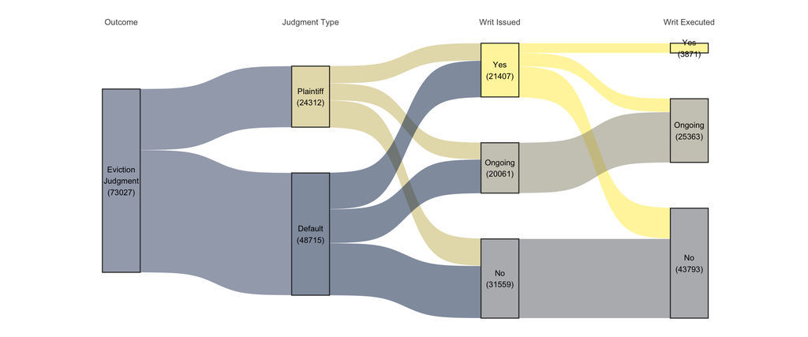

```r
# ggsankey version
# https://github.com/davidsjoberg/ggsankey
# https://rpubs.com/oomiwale1/926103

df_long <- writs_categories %>%
  make_long(outcome, disposition, writ_issued, writ_executed)

ggplot(df_long, aes(x = x, next_x = next_x,
                    node = node, next_node = next_node,
                    fill = node,
                    label = node)) +
  geom_sankey(alpha = 0.5,
              node.color = "grey20",
              show.legend = FALSE,
              space = NULL,
              width = .2,
              smooth = 6) +
  geom_sankey_text(aes(label = after_stat(paste0(node, "\n", "(", freq, ")"))),
                   color = "black", size = 3) +
  scale_fill_viridis_d(option = "cividis") +
  scale_x_discrete(labels = c("Outcome", "Judgment Type", "Writ Issued", "Writ Executed"),
                   position = "top") +
  labs(x = "") +
  theme_sankey() +
  theme(legend.position = "none")
```

Note: I need to change the labels on the writ executed column to gain more control over the colors in the ggsankey::geom_sankey version; but am concerned that will be more confusing to read.

### Additional thoughts

In a final version, I could imagine adding some background color to represent informal evictions. That is, extending the overall area of the figure by adding background color below the figure. The size of the background color would be approximately proportionate to an estimated number of non-court evictions, but in a way that acknowledges uncertainty (e.g, fuzzy edges or fading out).

Currently just playing with possible color themes, but always looking for suggestions on better uses of color.

Figures could also be oriented vertically to make them bigger.

## Case Filing to Writs

Alternatively, we could begin with a set of cases filed (here all cases filed beginning in January 2023) and include cases that do not result in a formal eviction ruling.

```r
# Starting with Cases
cases <- cases %>%
  mutate(dur_disp_date = interval(date_disposed, as.Date("2024-02-01")) / ddays(1),
         dur_writ_date = interval(writ_iss_date, as.Date("2024-02-01")) / ddays(1))

## derive measures
# Filing (Case Filed) ->
#   Outcome (Eviction, Non-Eviction, Ongoing) ->
#     Writ Issued (Yes, No, Ongoing) ->
#       Writ Executed (Yes, No, Ongoing)

cases_categories <- cases %>%
  mutate(filed = "Cases",
         outcome = case_when(
           str_detect(judgment, "Dismissed") ~ "Non-Eviction",
           judgment == "Non-suit" ~ "Non-Eviction",
           judgment == "Defendant" ~ "Non-Eviction",
           judgment == "Not Found/Unserved" ~ "Non-Eviction",
           judgment == "Other" ~ "Non-Eviction",
           judgment == "Transfer/Change of Venue" ~ "Non-Eviction",
           judgment == "null without prejudice" ~ "Non-Eviction",
           judgment == "Plaintiff" ~ "Eviction",
           is.na(judgment) ~ "Ongoing"
         ),
         # these should take into account time since disposition
         # do non-eviction cases need values here? (yes for now)
         writ_issued = case_when(
           # writs moot
           outcome == "Non-Eviction" ~ "No",
           # outcome is not present
           outcome == "Ongoing" ~ "Ongoing",
           # outcome is eviction and writ issued date is present
           outcome == "Eviction" & !is.na(writ_iss_date) ~ "Yes",
           # outcome is eviction, writ issue date is absent, but a writ could still happen
           outcome == "Eviction" & dur_disp_date <= 180 & is.na(writ_iss_date) ~ "Ongoing",
           # outcome is eviction, writ issue date is absent, and it's too late to request a writ
           outcome == "Eviction" & dur_disp_date > 180 & is.na(writ_iss_date) ~ "No",
           # cases with missing dur_disp_date?
           outcome == "Eviction" & is.na(dur_disp_date) ~ "No"
         ),
         # these should take into account time since issued
         # do non-eviction cases need values here? (yes for now)
         writ_executed = case_when(
           # writs moot
           outcome == "Non-Eviction" ~ "No",
           # outcome is not present
           writ_issued == "Ongoing" ~ "Ongoing",
           # outcome is eviction, writ is issued, writ execution date is present
           outcome == "Eviction" & writ_issued == "Yes" & !is.na(writ_exec_date) ~ "Yes",
           # outcome is eviction, writ is issued, writ execution date is absent, but within 30 days
           outcome == "Eviction" & writ_issued == "Yes" & is.na(writ_exec_date) & dur_writ_date <= 30  ~ "Ongoing",
           # outcome is eviction, writ is issued, writ execution date is absent, but over 30 days
           outcome == "Eviction" & writ_issued == "Yes" & is.na(writ_exec_date) & dur_writ_date > 30 ~ "No",
           # outcome is eviction, writ is ongoing
           outcome == "Eviction" & writ_issued == "Ongoing" ~ "Ongoing",
           # outcome is eviction, writ is absent (and can't be requested)
           outcome == "Eviction" & writ_issued == "No"  ~ "No"
         ))
```

### ggforce::geom_parallel_sets

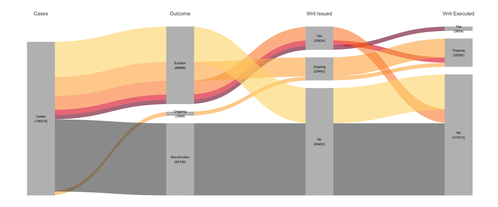

```r
## ggforce version
cases_wide <- cases_categories %>%
  count(filed, outcome, writ_issued, writ_executed) %>%
  mutate(color = c(1,2,3,4,5,6,7),
         color = factor(color))

cases_set <- cases_wide %>%
  gather_set_data(c("filed","outcome","writ_issued","writ_executed"))

cases_set <- cases_set %>%
  mutate(y = factor(y,
                    levels = c("Cases", "Eviction", "Yes", "Ongoing",
                               "Non-Eviction", "No")))

ggplot(cases_set, aes(x, id = id, split = y, value = n)) +
  geom_parallel_sets(aes(fill = color),
                     alpha = 0.6, axis.width = 0.1,
                     show.legend = FALSE) +
  geom_parallel_sets_axes(axis.width = 0.2, fill = "grey") +
  geom_parallel_sets_labels(aes(label = after_stat(paste0(label, "\n", "(", value, ")"))),
                            color = 'black', size = 2, angle = 0) +
  scale_x_continuous(labels = c("Cases", "Outcome", "Writ Issued", "Writ Executed"),
                     position = "top") +
  scale_fill_manual(values = c("#fed976", "#feb24c", "#fd8d3c", "#e31a1c", "#800026", "grey30", "#feb24c")) +
  labs(x = "") +
  theme_sankey()
```

### ggsankey::geom_sankey

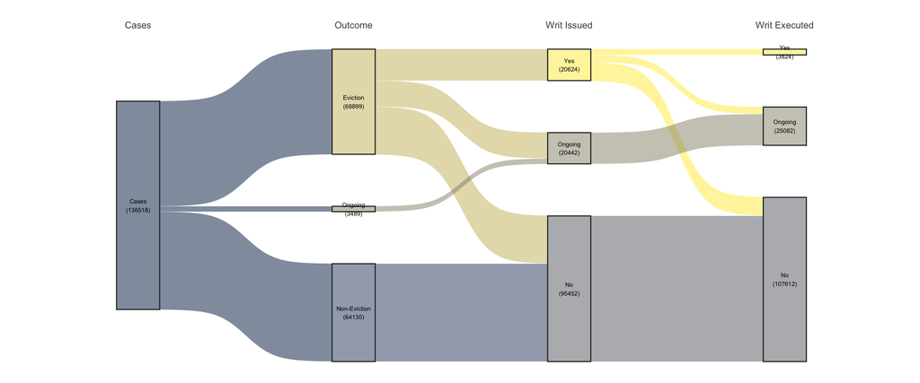

```r
## ggsankey version
# https://github.com/davidsjoberg/ggsankey
# https://rpubs.com/oomiwale1/926103

cases_long <- cases_categories %>%
  make_long(filed, outcome, writ_issued, writ_executed)

# alter order of nodes?
# first level is at bottom of plot?
cases_long <- cases_long %>%
  mutate(node = factor(node,
                       levels = c("Cases", "Non-Eviction", "No",
                                  "Ongoing", "Eviction", "Yes")),
         next_node = factor(next_node,
                            levels = c("Non-Eviction", "No", "Ongoing",
                                       "Eviction", "Yes")))


ggplot(cases_long, aes(x = x, next_x = next_x,
                    node = node, next_node = next_node,
                    fill = node,
                    label = node)) +
  geom_sankey(alpha = 0.5,
              node.color = "grey20",
              show.legend = FALSE,
              space = NULL,
              width = .2,
              smooth = 6) +
  geom_sankey_text(aes(label = after_stat(paste0(node, "\n", "(", freq, ")"))),
                   color = "black", size = 2) +
  scale_fill_viridis_d(option = "cividis") +
  scale_x_discrete(labels = c("Cases", "Outcome", "Writ Issued", "Writ Executed"),
                   position = "top") +
  labs(x = "") +
  theme_sankey() +
  theme(legend.position = "none")
```